# Introduction to Differential Expression Analysis

BME780 Guest Lecture

Author

Kris Sankaran

Published

September 23, 2026

[Source Code](https://github.com/krisrs1128/talks/blob/master/2026/20260923/20260923.qmd)

## Motivation

1. Comparison is fundamental to biological discovery. In the sequencing era, our comparisons are often based on large-scale molecular readouts.
   - In functional genomics, we compare molecular profiles before and after knocking out genes.
   - In cancer biology, we compare molecular profiles in cancer versus healthy tissue.
   - In microbiome studies, we compare microbial species communities before and after treatments.
   - In single cell eQTL studies, we look for cell-type-specific expression profiles that differs across genotypes.

   Viewed more abstractly, this is a problem of comparing the frequency of genomic features across conditions, potentially accounting for secondary factors, like timepoints or patient characteristics, that can also influence the observed frequencies.

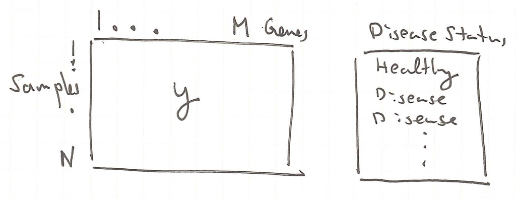

2. The overarching goal of differential expression analysis is to identify genomic features that vary systematically across conditions of interest. From an analysis perspective, there are two fundamental challenges:
   - The “usual” statistical assumptions do not immediately apply.
   - There may be thousands of features of potential interest. The more we analyze, the greater the risk that irrelevant features appear associated just by chance.

   The first problem motivates *normalization methods*, and the second motivates *multiple hypothesis testing methods*. There have been many proposals for both normalization and multiple hypothesis testing. We will focus on the specific procedure adopted by limma, though many of the ideas of this approach appear throughout the literature.

## Example

3. Before diving more deeply into the statistics, let’s look at a prawctical code example using the limma package. The block below loads our software packages and sets a random number seed for reproducibility.

   ```r
   library(limma)
   library(edgeR)
   library(tidyverse)
   library(airway)
   set.seed(20260923)
   ```

   We’ll analyze the [airway dataset](https://www.bioconductor.org/packages/release/data/experiment/html/airway.html), which comes from an RNA-seq experiment of how gene expression profiles change in smooth muscle tissue treated with dexamethasone. The data come from four cell lines, and for each line, there are paired treatment and control samples.

   ```r
   data(airway)
   airway
   ```

   ```
   class: RangedSummarizedExperiment
   dim: 63677 8
   metadata(1): ''
   assays(1): counts
   rownames(63677): ENSG00000000003 ENSG00000000005 ... ENSG00000273492
     ENSG00000273493
   rowData names(10): gene_id gene_name ... seq_coord_system symbol
   colnames(8): SRR1039508 SRR1039509 ... SRR1039520 SRR1039521
   colData names(9): SampleName cell ... Sample BioSample
   ```

4. This experiment object includes counts and context. The `assay` slot includes the counts of each gene transcript across the measured samples. The `rowData` and `colData` slots include contextual data about the genes and samples, respectively.

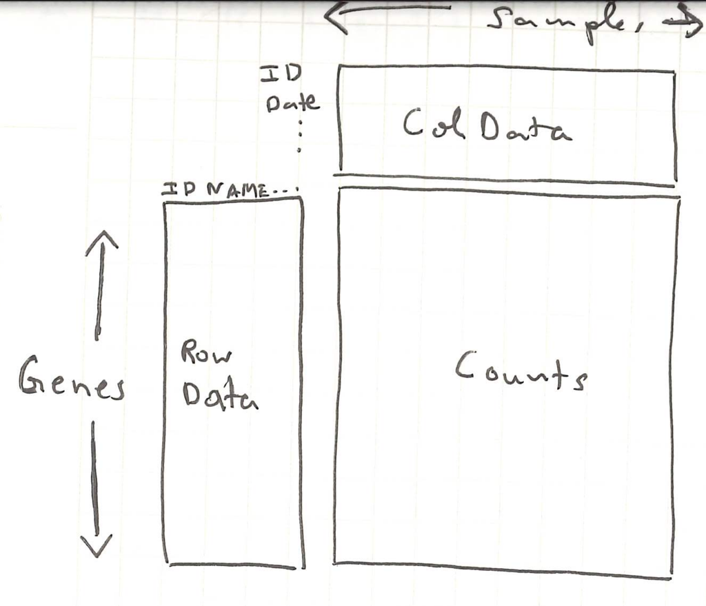

   This object was assembled by the `airway` package, but in practice, we would create our own using the `SummarizedExperiment` function, whose inputs are the counts matrix and the contextual data about each sample and gene. For any regression models that we run below, we will need the relevant variables to be defined as column names in the `colData`.

   ```r
   head(colData(airway))
   ```

   ```
   DataFrame with 6 rows and 9 columns
              SampleName     cell      dex    albut        Run avgLength
                <factor> <factor> <factor> <factor>   <factor> <integer>
   SRR1039508 GSM1275862  N61311     untrt    untrt SRR1039508       126
   SRR1039509 GSM1275863  N61311     trt      untrt SRR1039509       126
   SRR1039512 GSM1275866  N052611    untrt    untrt SRR1039512       126
   SRR1039513 GSM1275867  N052611    trt      untrt SRR1039513        87
   SRR1039516 GSM1275870  N080611    untrt    untrt SRR1039516       120
   SRR1039517 GSM1275871  N080611    trt      untrt SRR1039517       126
              Experiment    Sample    BioSample
                <factor>  <factor>     <factor>
   SRR1039508  SRX384345 SRS508568 SAMN02422669
   SRR1039509  SRX384346 SRS508567 SAMN02422675
   SRR1039512  SRX384349 SRS508571 SAMN02422678
   SRR1039513  SRX384350 SRS508572 SAMN02422670
   SRR1039516  SRX384353 SRS508575 SAMN02422682
   SRR1039517  SRX384354 SRS508576 SAMN02422673
   ```

   ```r
   head(rowData(airway))
   ```

   ```
   DataFrame with 6 rows and 10 columns
                           gene_id   gene_name  entrezid   gene_biotype
                       <character> <character> <integer>    <character>
   ENSG00000000003 ENSG00000000003      TSPAN6        NA protein_coding
   ENSG00000000005 ENSG00000000005        TNMD        NA protein_coding
   ENSG00000000419 ENSG00000000419        DPM1        NA protein_coding
   ENSG00000000457 ENSG00000000457       SCYL3        NA protein_coding
   ENSG00000000460 ENSG00000000460    C1orf112        NA protein_coding
   ENSG00000000938 ENSG00000000938         FGR        NA protein_coding
                   gene_seq_start gene_seq_end    seq_name seq_strand
                        <integer>    <integer> <character>  <integer>
   ENSG00000000003       99883667     99894988           X         -1
   ENSG00000000005       99839799     99854882           X          1
   ENSG00000000419       49551404     49575092          20         -1
   ENSG00000000457      169818772    169863408           1         -1
   ENSG00000000460      169631245    169823221           1          1
   ENSG00000000938       27938575     27961788           1         -1
                   seq_coord_system      symbol
                          <integer> <character>
   ENSG00000000003               NA      TSPAN6
   ENSG00000000005               NA        TNMD
   ENSG00000000419               NA        DPM1
   ENSG00000000457               NA       SCYL3
   ENSG00000000460               NA    C1orf112
   ENSG00000000938               NA         FGR
   ```

   ```r
   assay(airway)[1:4, 1:4]
   ```

   ```
                   SRR1039508 SRR1039509 SRR1039512 SRR1039513
   ENSG00000000003        679        448        873        408
   ENSG00000000005          0          0          0          0
   ENSG00000000419        467        515        621        365
   ENSG00000000457        260        211        263        164
   ```

   The first line below makes sure that `untrt` is the reference level, so a positive $t$-statistic is interpreted as the treatment being larger than the control. Limma expects the experiment object to be stored in a `DGEList` (“differential gene expression list”), which reorganizes the counts and context present in the original experiment object. The `SE2DGEList` function converts from `SummarizedExperiment` to `DGEList`.

   ```r
   airway$dex <- relevel(airway$dex, ref = "untrt")
   dge <- SE2DGEList(airway)
   ```

5. We next filter genes that are expressed at very low levels. The commands that follow normalize the data, which we discuss in detail below. The most important part of this code block is that `model.matrix` specifies the factors that influence gene expression. Here, both the cell line and the dexamethasone status are allowed to influence gene expression levels. This is encoded in the formula object `~ cell + dex`. Both variables were columns in the `colData` slot of our original experiment.

   ```r
   keep <- filterByExpr(dge, group = dge$samples$dex)
   dge <- normLibSizes(dge[keep, ])
   design <- model.matrix(~ cell + dex, data = dge$samples)
   v <- voom(dge, design, save.plot = TRUE)
   ```

6. We use the output from normalization as input for hypothesis testing. The `topTable` output shows genes that limma declares to be the most significantly different between dexamethasone and control settings. My point in showing the code here is that even though the statistical discussion below might seem long, the actual implementation is only a few lines.

   ```r
   fit_raw <- lmFit(v, design)
   fit <- eBayes(fit_raw)
   topTable(fit, coef = "dextrt")
   ```

   ```
                           gene_id gene_name entrezid   gene_biotype
   ENSG00000165995 ENSG00000165995    CACNB2       NA protein_coding
   ENSG00000120129 ENSG00000120129     DUSP1       NA protein_coding
   ENSG00000157214 ENSG00000157214    STEAP2       NA protein_coding
   ENSG00000162493 ENSG00000162493      PDPN       NA protein_coding
   ENSG00000189221 ENSG00000189221      MAOA       NA protein_coding
   ENSG00000162614 ENSG00000162614      NEXN       NA protein_coding
   ENSG00000101347 ENSG00000101347    SAMHD1       NA protein_coding
   ENSG00000125148 ENSG00000125148      MT2A       NA protein_coding
   ENSG00000139132 ENSG00000139132      FGD4       NA protein_coding
   ENSG00000106976 ENSG00000106976      DNM1       NA protein_coding
                   gene_seq_start gene_seq_end seq_name seq_strand
   ENSG00000165995       18429606     18830798       10          1
   ENSG00000120129      172195093    172198198        5         -1
   ENSG00000157214       89796904     89867451        7          1
   ENSG00000162493       13909960     13944452        1          1
   ENSG00000189221       43515467     43606068        X          1
   ENSG00000162614       78354198     78409580        1          1
   ENSG00000101347       35518632     35580246       20         -1
   ENSG00000125148       56642111     56643409       16          1
   ENSG00000139132       32552463     32798984       12          1
   ENSG00000106976      130965658    131017527        9          1
                   seq_coord_system symbol     logFC  AveExpr         t
   ENSG00000165995               NA CACNB2  3.278357 3.680801  33.82673
   ENSG00000120129               NA  DUSP1  2.938012 6.643013  28.39344
   ENSG00000157214               NA STEAP2  1.967389 6.788567  27.55911
   ENSG00000162493               NA   PDPN  1.881003 5.187898  27.48959
   ENSG00000189221               NA   MAOA  3.330552 5.949117  26.78834
   ENSG00000162614               NA   NEXN  2.028100 7.636408  26.08350
   ENSG00000101347               NA SAMHD1  3.755593 8.133814  25.62151
   ENSG00000125148               NA   MT2A  2.201202 7.022630  25.56297
   ENSG00000139132               NA   FGD4  2.221418 5.413899  25.31734
   ENSG00000106976               NA   DNM1 -1.766912 5.096501 -25.21379
                        P.Value   adj.P.Val        B
   ENSG00000165995 1.203221e-10 1.91625e-06 14.34587
   ENSG00000120129 5.570210e-10 2.07043e-06 13.68992
   ENSG00000157214 7.228166e-10 2.07043e-06 13.45660
   ENSG00000162493 7.389372e-10 2.07043e-06 13.39575
   ENSG00000189221 9.259452e-10 2.07043e-06 13.18925
   ENSG00000162614 1.168492e-09 2.07043e-06 12.99405
   ENSG00000101347 1.365561e-09 2.07043e-06 12.83329
   ENSG00000125148 1.393067e-09 2.07043e-06 12.82876
   ENSG00000139132 1.515402e-09 2.07043e-06 12.73254
   ENSG00000106976 1.570514e-09 2.07043e-06 12.68717
   ```

## Linear Models Background

7. The machinery that underlies both normalization and multiple hypothesis testing is the linear model. We briefly detour to review the mechanics of hypothesis testing through linear models. There will be math, but the math is necessary to make our understanding precise.
8. Let $y_n$ represent gene expression levels across samples $n$. Imagine that data come from two groups (e.g., healthy and disease, or knockout and control) and that are both Gaussian distributed. The groups may have different means $\mu$ but are required to have the same variances $\sigma^2$.

   $$\begin{align}
   y_{n} \sim
   \begin{cases}
   \mathcal{N}\left(\mu_{A}, \sigma^2\right) & \text{for } n \in \text{Group A} \\
   \mathcal{N}\left(\mu_{B}, \sigma^2\right) & \text{for } n \in \text{Group B}
   \end{cases} \end{align}$$

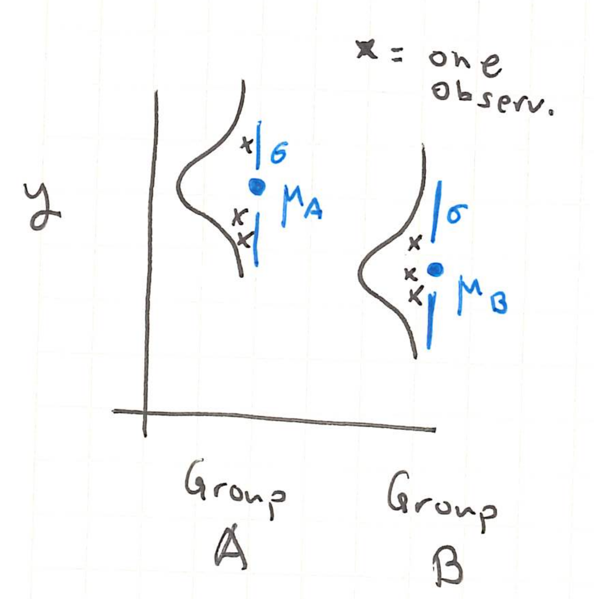

   If we want to see whether the true (unobserved) group means are the same, we can compute,

   $$t = \frac{\bar{y}_A - \bar{y}_B}{s\sqrt{1/N_A + 1/N_B}}.$$

   This is the differences in observed means of groups A and B, adjusted according to an empirical estimate $s^2$ of the within-group variance[^1]. This adjustment accounts for the spread within each group when interpreting the difference in means.
9. We will say that when the means of the two groups are equal, the null hypothesis holds. The reason for the naming is that when the two groups have the same mean, there is no need to further examine subgroup differences (null $\iff$ nothing more to look at). Formally, this is denoted,

   $$H_{0}: \mu_{A} = \mu_{B}$$

   Even when $H_{0}$ holds, the observed difference in sample means will be nonzero on any actual dataset, and therefore $t \neq 0$. In the plot below, the normal densities denote the true data distributions in each group, the points represent the observed data, and the horizontal lines reflect the observed sample means.

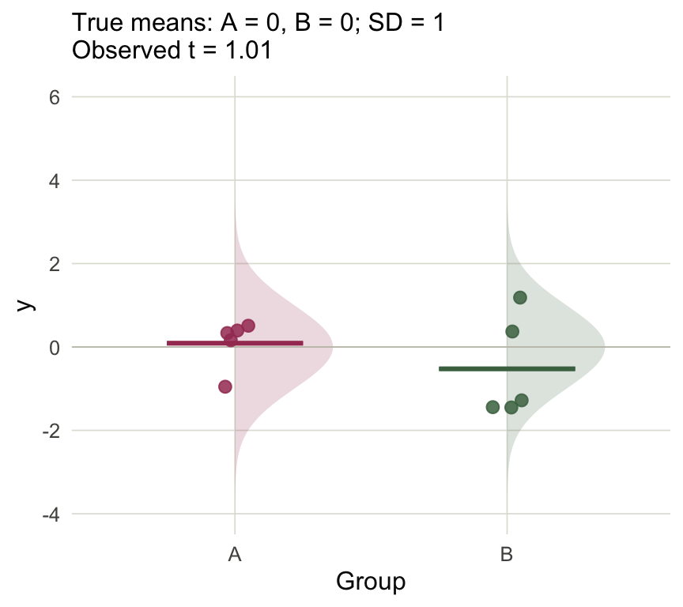

   Figure 1

   However, the further the statistic $t$ is from zero (either negative or positive), the less plausible the null hypothesis $H_0$ becomes. The example below is a case where $H_{0}$ does not hold, and this is reflected in the relatively larger $t$-statistic.

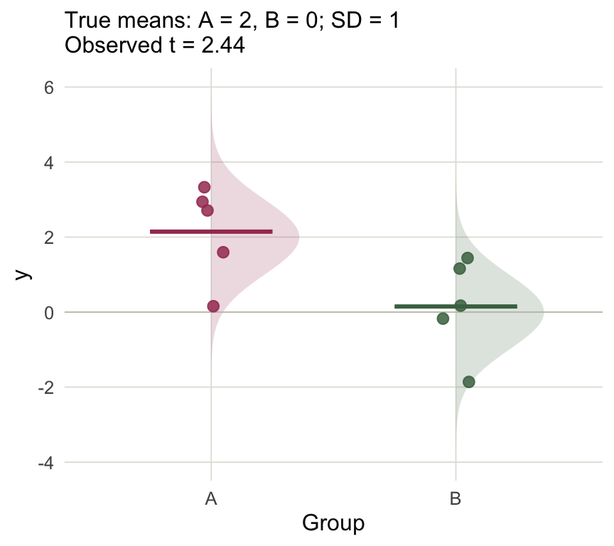

   Figure 2

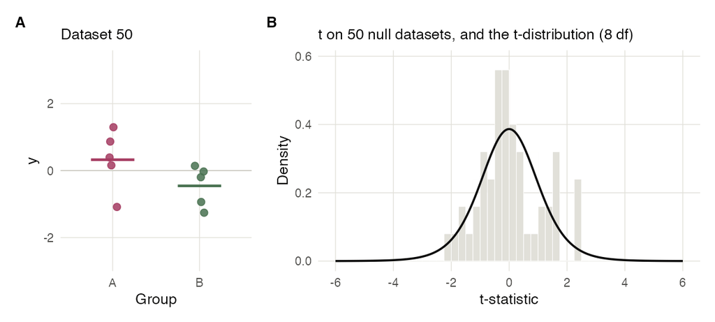

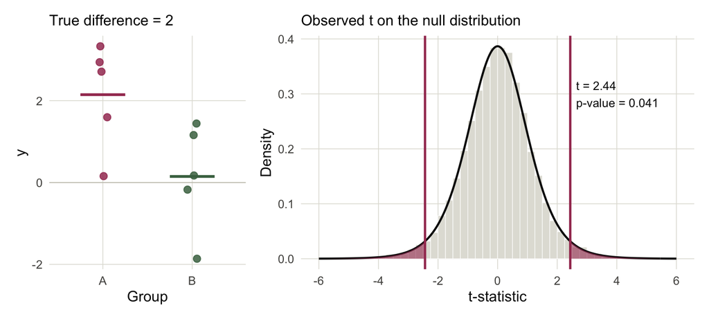

    Figure 3

    This is the essential logic of hypothesis testing: if we see a statistic that doesn’t fall into the bulk of the null distribution, then we have evidence that the null hypothesis is false. A $p$-value is defined as the area of the distribution with larger magnitude than the test statistic, and it is a measure of the strength of this evidence (smaller area $\to$ less likely to come from the null).
12. So if we’re willing to believe the Gaussian assumption, we have a procedure for comparing means across two groups. But in genomics, we often want to analyze several factors at once, either because we have several treatments to give simultaneously or because we need to control for secondary factors. For many centuries, the guiding principle was to analyze one factor at a time, varying one but fixing all the others. This would mean working with separate subsets of data.
13. One of the major insights of statistics is that it can be beneficial to analyze multiple factors at once, because it allows you to share evidence across all subsets[^3]. The idea is to proceed like in Figure 4, where we care about the difference between A and B, but the response is influenced by a secondary factor $x_n$. If we subsampled into data within a narrow range of $x_n$, then we would be discarding most of the information. Conversely, if we ignored this factor and only compared the $y_n$ values, then the groups would become more blended and we would struggle to detect a difference.

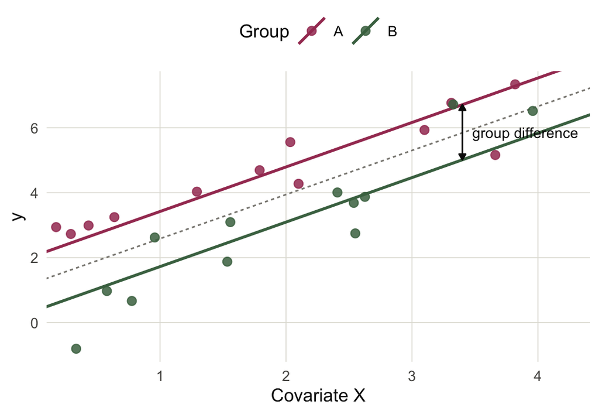

    Figure 4

14. In this case we might want to test the null hypothesis $H_{0}$ that the lines for the two groups are exactly overlapping. The main trick is to subtract out the effects from the $x_n$ and see whether there still remains a difference between the two groups. That is, after subtracing the $x_n$ effects (i.e., looking at the gaps between the points and the dashed line), we return to the setting above.

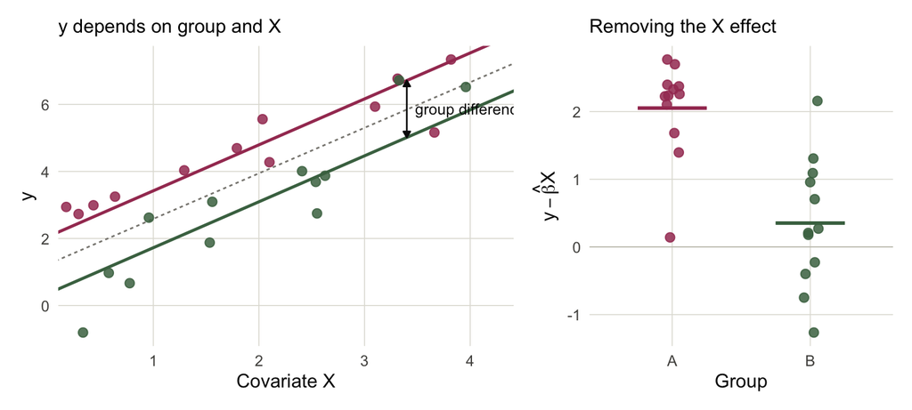

    Figure 5

    This is exactly what a linear model does. The formula becomes more complicated, but we can again derive a $t$-statistic that has a closed form null distribution under $H_{0}$.
15. The fact that we can make comparisons between groups while accounting for the influence of many factors is what makes linear models such a versatile statistical method. The example here uses a straight line for $x_n$ but the same machinery works generally, including when the effects are nonlinear, when the slopes of the lines are not parallel, and when we have a treatment with more than two levels.

## Normalization

16. Unfortunately the Gaussian assumption doesn’t make sense for genomics data. But the literature has found ways to salvage their applicability. This is done is through a process called normalization, and it lies at the heart of limma.
17. There are two issues that stand in the way of making the Gaussian assumption. The first is that sequencing assays return counts of different genomic features, and these are not continuous measurements like the Gaussian. The second is that each sample’s mean can depend on its sequencing depth. Sequencing depth is a technical factor that can obscure the actual biological differences between conditions.
18. An idea that addresses both problems is the log counts-per-million (CPM) transformation. Suppose that the expression for gene $g$ in sample $n$ is $y_{ng}$. Arrange all these data into a samples-by-genes matrix[^4] $Y \in \mathbb{R}^{N\times G}$. The logCPM transformation is,

    $$y_{ng} \rightsquigarrow \log\left(\frac{y_{ng} + \frac{1}{2}}{\sum_{k}y_{nk} + 1} \times 10^{6}\right)$$

    The $\frac{1}{2}$ and $1$ offfsets help us avoid $\log\left(0\right)$, which is undefined. Besides this, the fraction inside of the log converts each sample into something like a relative frequency of gene $g$ in sample $n$ (it would be exactly this without the offsets). This removes differences in sequencing depths. The $10^6$ is where the “per-million” name comes from. Finally, by taking the log transformation, we convert discrete counts into a continuous scale where the normal distribution assumption is more believable.
19. The three genes in Figure 6 are shown before and after applying the CPM transformation. The data are described in more detail in the code example below. For XIST, the Gaussian approximation makes much more sense after the transformation.

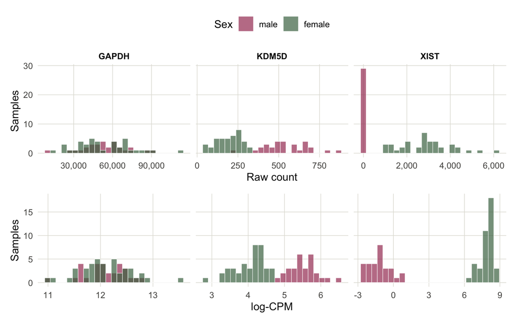

    Figure 6

    At this point, we can, in principle, fit a linear model where the experimental factors are features $x_{n}$ and the transformed gene expression is the response $y_n$.
20. But there are still issues. When we convert to frequencies, we’re losing a meaningful information about the precision of our measurements. Two samples can have exactly the same logCPM value for a gene but different total counts. The total count information is important because a sample with deep sequencing is measured more accurately than one with shallow sequencing.
21. This shows up in the spread of the groups after the logCPM transformation has been applied. For example, in Figure 7[^5], the logCPM transformation has put all the genes on roughly the same scale. Instead of ranging from 0 to 40,000, they’re in roughly the range from -5 to 10.

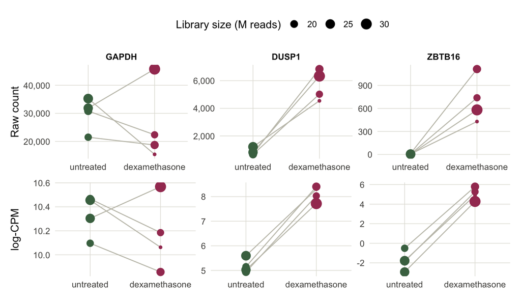

    Figure 7

    But notice that the ZBTB16 gene has more variation within each group compared to the other two genes. In statistical language, this is called the residual variation (after residualizing out the group effect), and it happens to be a general phenomenon that genes with smaller sequencing depth also have larger residual variation after the logCPM transformation.

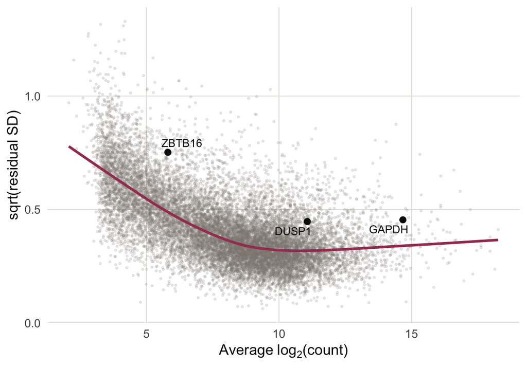

    Figure 8

22. Limma uses this trend to reweight the observations. The curve above was learned using gene-level quantities. But we can compute the quantity on the x-axis for any count $y_{ng}$, and this suggests an associated weight, called the precision weight. Intuitively, if an observation comes from a sample with deep sequencing, it will have higher precision.

    These weights can then be incorporated into linear models through weighted linear regression. For example in the simple case where we’re simply looking at the difference between two groups, we would compute a weighted average instead of a plain average.

## Multiple Hypothesis Testing

23. At this point, we could imagine applying a linear model to every single genomic feature. We would have a separate null hypothesis associated with each gene. We would reject those where the groups means seem different (controlling for other factors). The resulting list of significant genes would be the ones that we prioritize for follow-up analysis.
24. This doesn’t quite work, though. It’s easiest to understand through a small example. I’ve simulated a thousand hypothetical genes from two groups. For every gene, I simulated variances $\sigma_{g}^{2}$ from a uniform distribution between 0.5 and 2, so some have expression that stay closer to their mean than others. For 50 of these genes, I introduce a true difference of 2.5 between the means[^6]. In the language of the two-groups model above, $\mu_{A} = 0, \mu_{B} = 2.5$. I sample only two replicates per group (four samples total).
25. Figure 9a shows the 50 genes with the most significant $t$-statistics. Only 11 are actually related to the treatment! Of the top 10 genes, only two are actually relevant.

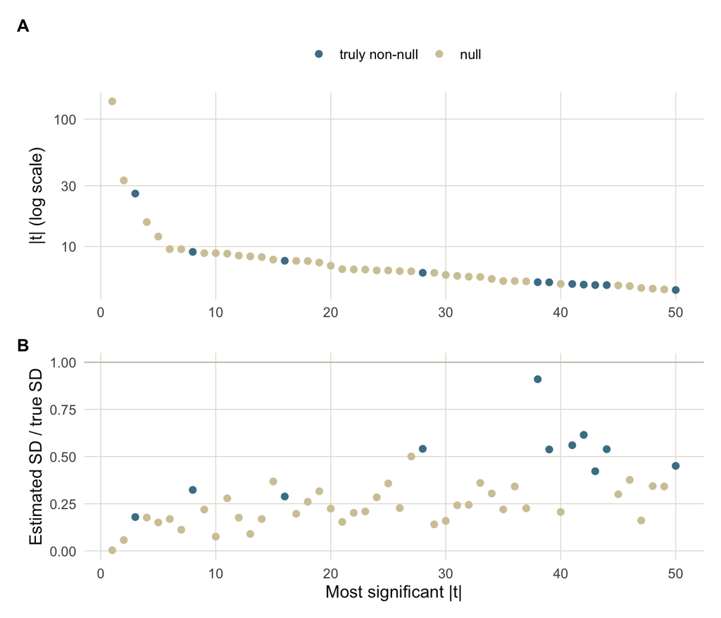

    Figure 9

    Figure 9b is the critical clue. The genes that appear most significant actually just have estimated variances $s_{g}^2$ that are smaller than their true variances $\sigma_{g}^2$, which we know in the simulation, but which we wouldn’t know in reality. The problem is that with small sample sizes, we might have a small empirical variance just by chance, and since the $t$-statistic divides by $s_g$, we end up overestimating the associated genes’ significance.

    $$t_{g} = \frac{\bar{y}_{A,g} - \bar{y}_{B,g}}{s_{g}\sqrt{1/N_A + 1/N_B}}.$$
26. When we observe a small $s_{g}^2$, it could either be because the gene truly has small variation around its mean, or we just got replicates that are unusually close to each other. The major insight of limma is that the other genes can help us tell which of these two situations we are in.

    To this end, suppose we had a prior $H$ for the genewise variances,
    $$\sigma_{g}^{2} \overset{\text{iid}}{\sim} H$$
    This captures our prior knowledge about how much variation is expected in each group. Since the distribution of $s_{g}^2$ given $\sigma_{g}^{2}$ has a known form, it is possible to compute a posterior for each gene $g$,
    $$p\left(\sigma_{g}^2 \vert s_{g}^2\right).$$
    This posterior gives a better estimate of $\sigma_{g}^2$ which we can use in place of $s_{g}^2$. Figure 10 shows the prior-to-posterior update for gene YWHAB, which had the smallest estimated $s_{g}^2$.

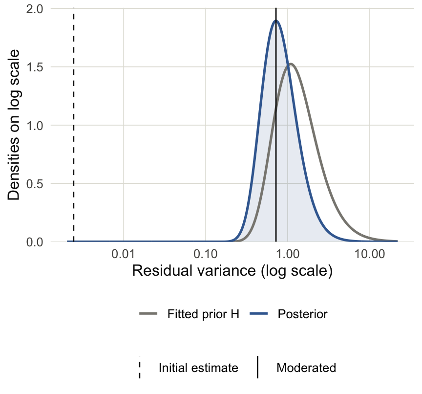

    Figure 10

    How did limma choose the prior $H$? It turns out that it is possible to estimate $H$ by looking at the $s_{g}^2$ across all the genes. This is what is meant by limma performing empirical Bayes. Compared to standard Bayesian inference, where the prior must simply be assumed, we can use the many parallel genes to form an “empirical” prior $\hat{H}$, which can then flow into the posterior calculations.
27. A consequence of these updated $\sigma_{g}^2$ estimates is that the new, “moderated” $t$-statistics are less affected by small values of $s_{g}^2$. Looking across all genes, Figure 11 shows that the $t$-statistics are shrunken towards zero. The genes that are shrunken the most are those whose $s_{g}^2$ were much lower than expected after estimating the prior variance $H$.

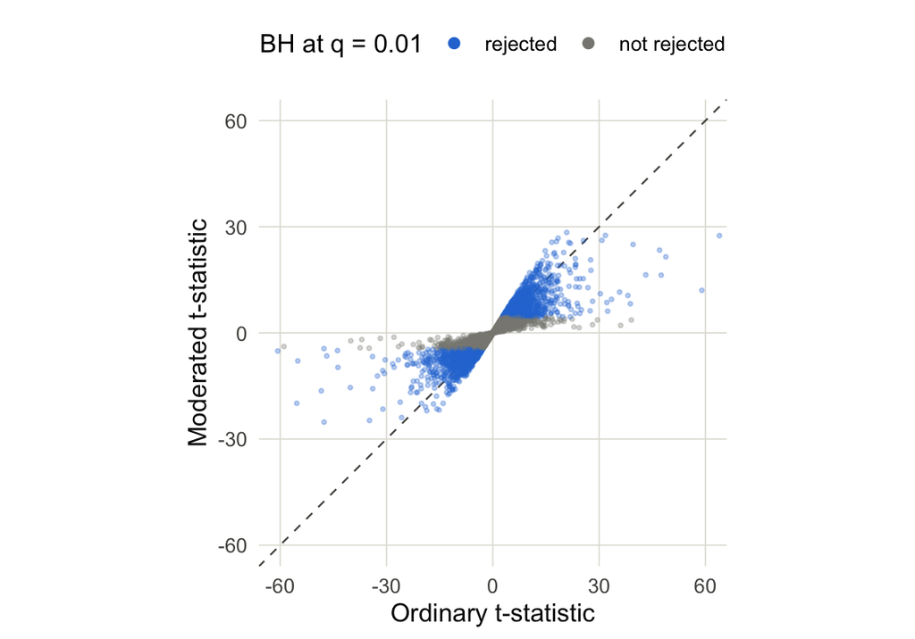

    Figure 11

    When using these $t$-statistics instead of the original ones, we have fewer false positives among our top-ranked genes. For example, returning to our earlier simulation, we can see that ranking using the moderated $t$-statistics leads to many fewer false positives and is nearly as good as using the ground truth standard deviation.

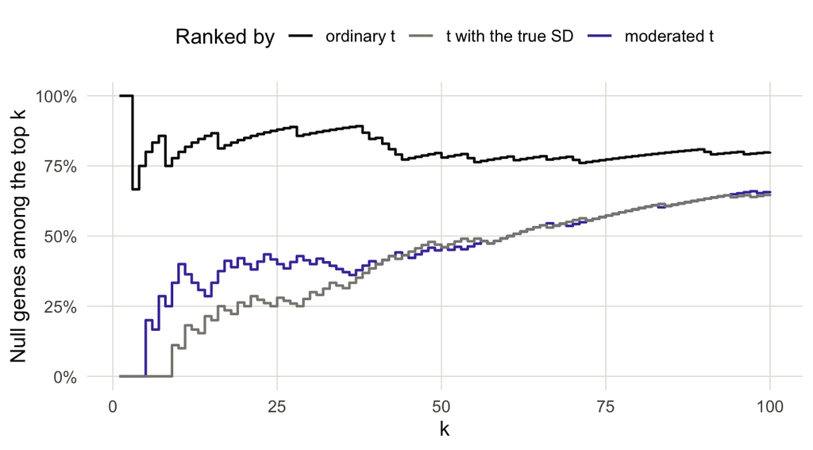

    Figure 12

28. There’s one last statistical consideration. If we use the usual hypothesis testing cutoffs then we’re liable to return many false positives…

    The problem is that the hypothesis testing cutoffs were originally designed so that, under the null hypothesis, the probability of a false positive is $\alpha$ (usually 0.05). But as we test more and more hypotheses, the probability of encountering at least one false positive grows.
29. To deal with this phenomenon (Benjamini and Hochberg 1995) had the idea that instead of controlling the probability of a single false positive, we should control the proportion of false positives among all rejections. Formally, let $H_{1}, \dots, H_{G}$ represent the null hypothesis for the $G$ genes. Suppose we obtain p-values $p_{1}, \dots, p_{G}$ and that $R$ of these $p$-values are smaller than $\alpha$. The $R$ rejections are the discoveries we would comment on in our paper. Among them, suppose that $V$ are false discoveries (in practice, we would never know this). The quantity

    $$\widehat{\mathrm{FDP}} = \frac{V}{R\vee 1}$$
    is the empirical false discovery proportion in this one experiment and its expected value across many experiments with the same underlying distribution is called the false discovery rate,
    $$\mathrm{FDR} = \mathbb{E}\left[\widehat{\mathrm{FDP}}\right]$$
30. In addition to introducing this quantity, Benjamini and Hochberg proposed a way of adjusting the $p$-value cutoffs $\alpha_{k}$ so that if we reject hypotheses using these cutoffs instead of $\alpha$, we would provably control the false discovery rate. Their procedure is now called the Benjamini-Hochberg (or BH) procedure, and the thresholds $\alpha_{k}$ are plotted as the magenta line in panel (B) below.
    - Sort the $G$ p-values in increasing order,
      $$p_{(1)} \le p_{(2)} \le \cdots \le p_{(G)}$$
      and denote the associated nulls by $H_{(1)}, \dots, H_{(G)}$.
    - Fix an FDR target $q$[^7] and define new thresholds $\alpha_{k} = \frac{kq}{G}$. This means that the smallest p-value is compared to the strictest threshold, the next smallest is compared to a slightly more lenient one, etc.
    - Find the largest $k$ where $p_{(k)} \le \alpha_{k}$, and reject $H_{(1)}, \dots, H_{(k)}$. If there is no such $k$, don’t reject anything.

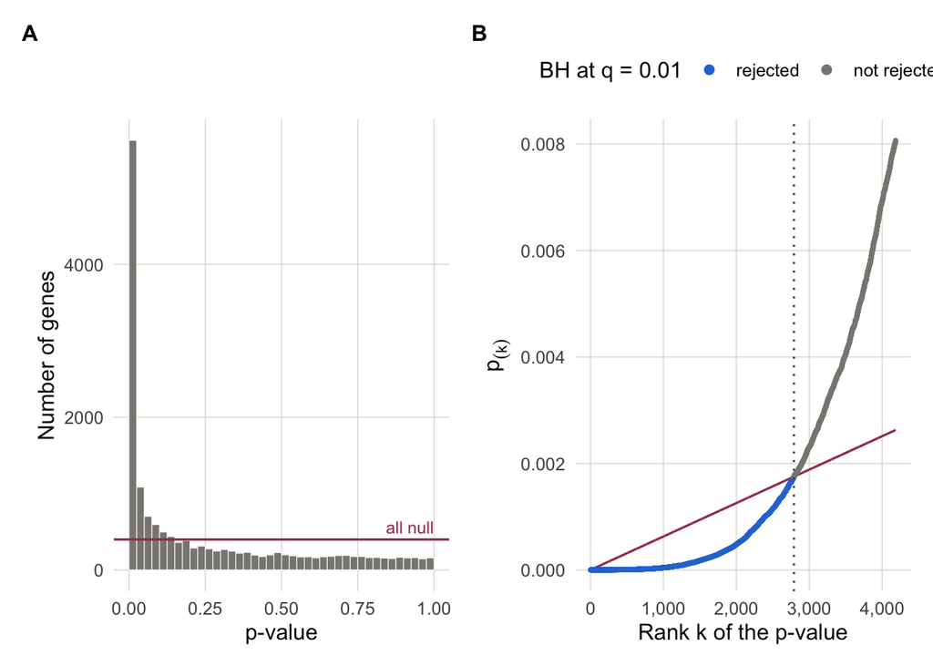

31. This procedure can be justified through the histogram of $p$-values, like those in panel (A) above. These $p$-values can be intuitively understood as a mixture of those from significant genes (large peak with small $p$-values) and those from nulls (everything else). Let $\pi_{0}$ denote the histogram density after the peak levels off. When many of the hypotheses are null, then the peak would be smaller and $\pi_{0}$ would be larger[^8].

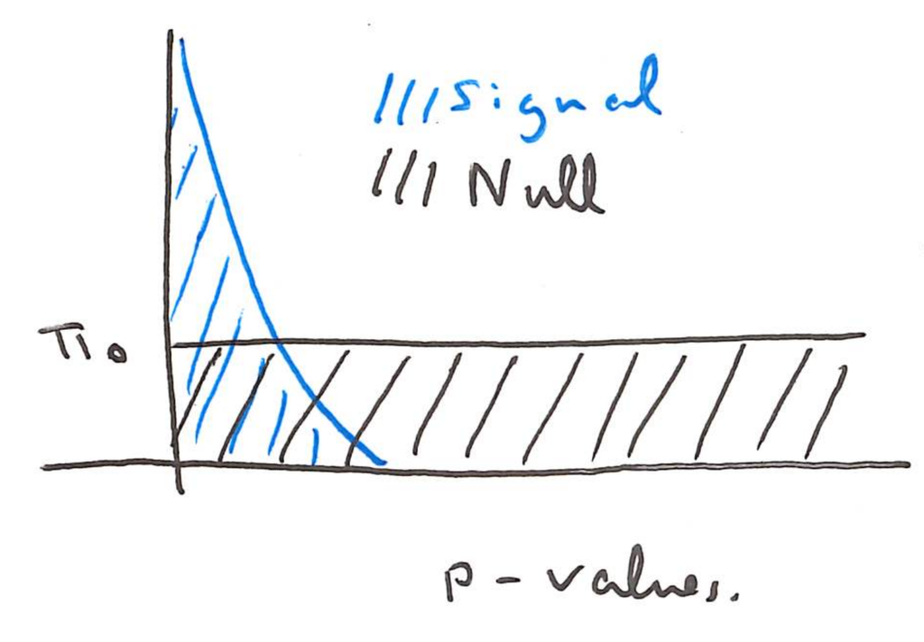

    Normalize the histogram to have the total area of 1, so each gene has weight $\frac{1}{G}$. If we let $R\left(t\right)$ give the total number of rejections below a threshold $t$, the corresponding area to the left of this histogram is $\frac{R\left(t\right)}{G}$.

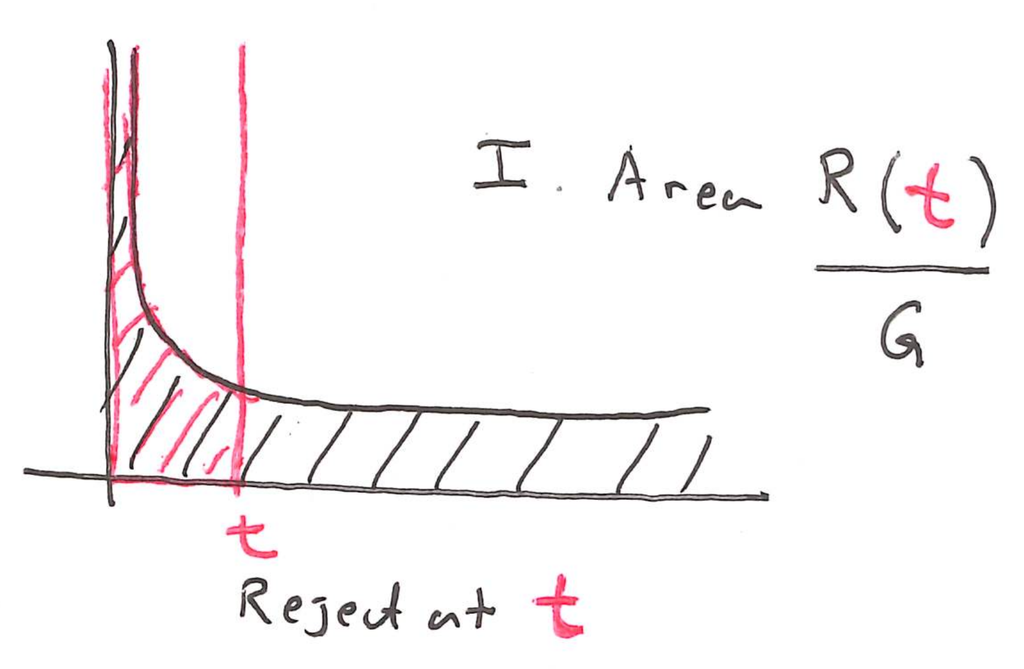

    How much of this area do we think comes from the null hypotheses? A reasonable estimate is $\pi_{0}t$.

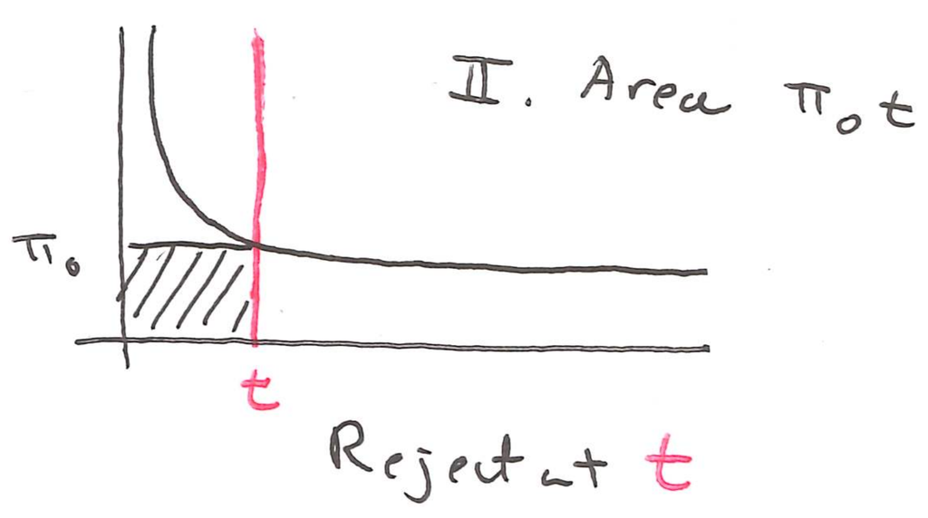

    So, a good estimate of the false discovery rate is the second area divided by the first,

    $$\mathrm{FDR}\left(t\right) \approx \frac{G\pi_{0}t}{R\left(t\right)}.$$
32. How might we choose $t$ so that the FDR is controlled below a target level $q$? Suppose we set $t$ to the $k^{th}$ largest $p$-value, $p_{\left(k\right)}$. Then we would have $k$ rejections, i.e. $R\left(t\right) = k$. Substituting this into $t$ and $R\left(t\right)$, we find,

    $$\begin{align}
    \mathrm{FDR}\left(t\right) \leq q
    \iff \frac{G \pi_{0} p_{\left(k\right)}}{k} \leq q
    \iff p_{\left(k\right)} \leq \frac{kq}{G \pi_{0}}.
    \end{align}$$

    Approximating[^9] $\pi_{0} \approx 1$ (i.e., most genes are null), the right hand side is $\alpha_{k}$. So, if we want to reject as many hypothesis as possible while controlling the FDR below $q$, then we should choose the largest $p_{\left(k\right)} \leq \alpha_{k}$. This is exactly the BH procedure.
33. This isn’t exactly a proof, but hopefully it gives some intuition about where the BH procedure came from. Finally, while it’s nice to know where the multiple testing correction comes from, we never have to compute the Benjamini-Hochberg thresholds ourselves. When we run `topTable`, limma automatically performs this multiple testing correction.

## Extra Code Example

34. Next we’ll study data from Pickrell et al. (2010), who gathered RNA-seq data from lymphoblastoid cell lines across 69 HapMap donors. Later research has focused on sex differences in gene expression, which we’ll analyze here. Compared to the motivating airway example, the sample size is much larger. This makes the moderated $t$-statistics less essential, as we will see.

    ```r
    library(tweeDEseqCountData)
    data(pickrell1)

    counts <- exprs(pickrell1.eset)
    samples <- data.frame(sex = factor(pickrell1.eset$gender), row.names = colnames(counts))
    genes <- data.frame(gene_id = rownames(counts), row.names = rownames(counts))
    dge <- DGEList(counts = counts, samples = samples, genes = genes)
    dge
    ```

    ```
    An object of class "DGEList"
    $counts
                    NA18486 NA18498 NA18499 NA18501 NA18502 NA18504 NA18505 NA18507
    ENSG00000127720       6      32      14      35      14      10      23      19
    ENSG00000242018      20      21      24      22      16      13      11       6
    ENSG00000224440       0       0       0       0       0       0       0       0
    ENSG00000214453       0       0       0       0       0       0       0       0
    ENSG00000237787       0       0       1       0       0       1       0       0
                    NA18508 NA18510 NA18511 NA18516 NA18517 NA18519 NA18520 NA18522
    ENSG00000127720      16      10      32      30      18      15      13      30
    ENSG00000242018      19      19      25      18      40      32      25      27
    ENSG00000224440       0       0       0       0       0       0       0       0
    ENSG00000214453       0       0       0       0       0       0       0       0
    ENSG00000237787       0       0       0       0       0       0       0       0
                    NA18523 NA18852 NA18853 NA18855 NA18856 NA18858 NA18861 NA18862
    ENSG00000127720       5      20      11      12      18      23      22      37
    ENSG00000242018      18      20      16      28       4      19      11      19
    ENSG00000224440       0       0       0       0       0       0       1       0
    ENSG00000214453       0       0       0       0       0       0       0       0
    ENSG00000237787       0       0       0       0       0       0       0       0
                    NA18870 NA18871 NA18909 NA18912 NA18913 NA18916 NA19093 NA19098
    ENSG00000127720      23      15      21      15       8      29      22      17
    ENSG00000242018      16      19      18       7      40      20      28      34
    ENSG00000224440       0       0       0       0       0       0       0       0
    ENSG00000214453       0       0       0       0       0       0       0       0
    ENSG00000237787       0       0       0       0       0       0       0       0
                    NA19099 NA19101 NA19102 NA19108 NA19114 NA19116 NA19119 NA19127
    ENSG00000127720      22      35       6      36      10      23       6      16
    ENSG00000242018      27      37       5      21      15      32       8      12
    ENSG00000224440       0       0       0       0       0       0       0       0
    ENSG00000214453       0       0       0       0       0       0       0       0
    ENSG00000237787       0       1       0       0       0       0       0       0
                    NA19128 NA19130 NA19131 NA19137 NA19138 NA19140 NA19143 NA19144
    ENSG00000127720      17      35      17      15      16      13      14       6
    ENSG00000242018      18      14      35      20      31      11      32      56
    ENSG00000224440       0       0       0       0       0       0       1       0
    ENSG00000214453       0       0       0       0       0       0       1       0
    ENSG00000237787       0       1       0       1       0       0       0       0
                    NA19147 NA19152 NA19153 NA19159 NA19160 NA19171 NA19172 NA19190
    ENSG00000127720      11      31      14       3      13      21      13      12
    ```

    [output cut: 20 more lines]

    ```
    NA18486     1  8042929            1   male
    NA18498     1 14133442            1   male
    NA18499     1  8888475            1 female
    NA18501     1  8877946            1   male
    NA18502     1 13818485            1 female
    64 more rows ...

    $genes
                            gene_id
    ENSG00000127720 ENSG00000127720
    ENSG00000242018 ENSG00000242018
    ENSG00000224440 ENSG00000224440
    ENSG00000214453 ENSG00000214453
    ENSG00000237787 ENSG00000237787
    38410 more rows ...
    ```

35. As before, the first step is to filter genes that have low expression. This reduces the data from 38410 to 18189 rows (we have so many genes because RNA-seq picks up on the noncoding RNAs).

    ```r
    keep <- filterByExpr(dge, group = dge$samples$sex)
    dge <- normLibSizes(dge[keep, ])
    ```

36. Next we apply the logCPM normalization and recover expression weights. This depends on the `design` because the residual variances are computed after the initial regression onto `sex`.

    ```r
    design <- model.matrix(~sex, data = dge$samples)
    v <- voom(dge, design)
    ```

37. The weights and original design are passed to the linear model, and the variances are shrunk towards the prior mean in the empirical Bayes step.

    ```r
    fit_raw <- lmFit(v, design)
    fit <- eBayes(fit_raw)
    ```

    Plotting the original vs. moderated $t$-statistics shows that, with more samples, the empirical bayes shrinkage step has less effect than it did in the airway dataset.

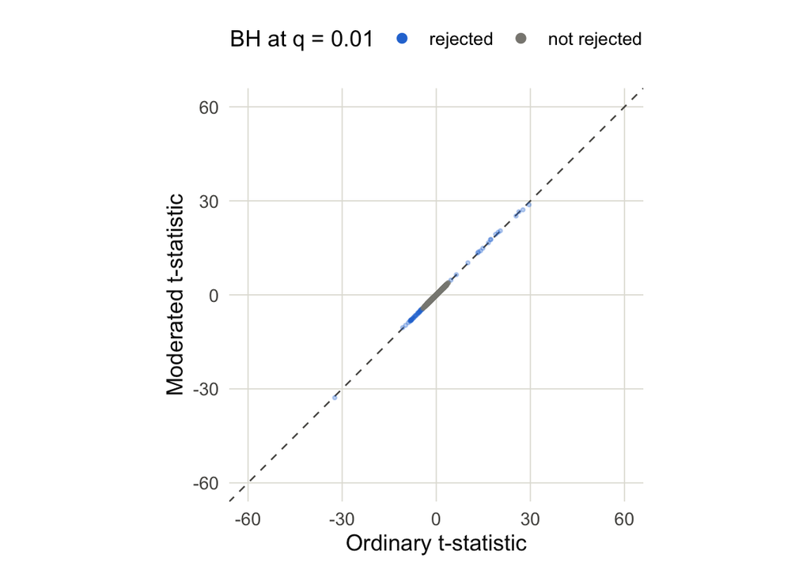

    Figure 13

38. Looking up[^10] the most significant genes, we see that the [first](https://www.ncbi.nlm.nih.gov/gene/140032) and [third](https://www.ncbi.nlm.nih.gov/gene/246126) are Y-linked and the [second](https://www.ncbi.nlm.nih.gov/gene/7503?utm_source=gemini) is associated with X inactivation.

    ```r
    topTable(fit, coef = "sexmale")
    ```

    ```
                            gene_id     logFC    AveExpr         t      P.Value
    ENSG00000157828 ENSG00000157828  3.279797  3.2532194  26.51460 9.557738e-39
    ENSG00000229807 ENSG00000229807 -9.870080  3.7534964 -32.82863 6.945854e-45
    ENSG00000099749 ENSG00000099749  4.258610  0.2597763  27.13339 2.124809e-39
    ENSG00000240326 ENSG00000240326  5.117366 -2.3026091  28.75200 4.739543e-41
    ENSG00000233864 ENSG00000233864  4.899016 -0.6087085  25.15769 2.864200e-37
    ENSG00000198692 ENSG00000198692  2.397292  2.6257697  20.44090 1.345501e-31
    ENSG00000213318 ENSG00000213318  4.300352  2.2105576  19.31123 4.248931e-30
    ENSG00000129824 ENSG00000129824  2.780009  4.6569064  17.59789 1.047233e-27
    ENSG00000131002 ENSG00000131002  5.442228 -0.2258336  19.96277 5.704941e-31
    ENSG00000183878 ENSG00000183878  1.877358  2.6881117  16.60785 2.954160e-26
                       adj.P.Val        B
    ENSG00000157828 4.346143e-35 73.88672
    ENSG00000229807 1.263381e-40 68.25105
    ENSG00000099749 1.288272e-35 66.09101
    ENSG00000240326 4.310378e-37 62.48315
    ENSG00000233864 1.041939e-33 59.81065
    ENSG00000198692 4.078886e-28 59.22512
    ENSG00000213318 9.660475e-27 55.10891
    ENSG00000129824 1.904813e-24 51.81093
    ENSG00000131002 1.482388e-27 51.02045
    ENSG00000183878 4.884838e-23 48.18882
    ```

## Learning More

39. All the figures in this notebook are created using code that’s directly executed inline. All the statistical quantities, like the moderated t-statistics and the prior and posterior variances, were extracted from limma. You can rerun our [source code](https://github.com/krisrs1128/talks/blob/master/2026/20260923/20260923.qmd) to get hands-on experience, and I encourage you to try making these kinds of plots on your own data.
40. You can find many more code examples in the Limma [online manual](https://bioconductor.org/packages/release/bioc/vignettes/limma/inst/doc/usersguide.pdf).
41. Limma is just one strategy for multiple testing with RNA-seq data. Another Bioconductor-based approach is DESeq2 (Love et al. 2014). It applies generalized linear models rather than linear models, which is a bit more conceptually advanced. But the software is also well developed and the key concepts like normalization, empirical Bayesian shrinkage, and multiple testing all carry over.
42. The simulation in the multiple testing section was inspired by a similar one in (Ji and Liu 2010). It also motivates a Bayesian approach to sharing information across genes. A deep Empirical Bayesian analysis of the limma is given by (Ignatiadis and Sen 2025). What the original limma paper presents as a somewhat ad hoc recipe this paper shows is an immediate consequence of some basic (and reasonable) statistical assumptions.
43. [Chapter 6](https://web.stanford.edu/class/bios221/book/06-chap.html#multiple-testing) of (Holmes and Huber 2019) gives a great introduction to multiple testing in high-throughput omics, and it’s available for free online.

## References

Benjamini, Yoav, and Yosef Hochberg. 1995. “Controlling the False Discovery Rate: A Practical and Powerful Approach to Multiple Testing.” *Journal of the Royal Statistical Society Series B: Statistical Methodology* 57 (1): 289–300. https://doi.org/10.1111/j.2517-6161.1995.tb02031.x.

Holmes, Susan, and Wolfgang Huber. 2019. *Modern Statistics for Modern Biology*. Cambridge University Press.

Ignatiadis, Nikolaos, and Bodhisattva Sen. 2025. “Empirical Partially Bayes Multiple Testing and Compound Χ2 Decisions.” *The Annals of Statistics* 53 (1). https://doi.org/10.1214/24-aos2431.

Ji, Hongkai, and X Shirley Liu. 2010. “Analyzing’omics Data Using Hierarchical Models.” *Nature Biotechnology* 28 (4): 337–40.

Love, Michael I, Wolfgang Huber, and Simon Anders. 2014. “Moderated Estimation of Fold Change and Dispersion for RNA-Seq Data with DESeq2.” *Genome Biology* 15 (12): 550.

## Footnotes

[^1]: Ideally $s^2 \approx \sigma^2$
[^2]: A $t$-distribution with eight degrees of freedom.
[^3]: Stephen Stigler lists this as #6 in his [“7 Pillars of Statistical Wisdom”](https://www.hup.harvard.edu/books/9780674088917).
[^4]: This is the transpose of the format used in `SummarizedExperiment`, but it is more common to write in this format in statistics.
[^5]: From the airway dataset above.
[^6]: The rest have means all equal to zero.
[^7]: This is the analog of $\alpha$ in ordinary hypothesis testing
[^8]: In fact, $\pi_{0}$ exactly corresponds to the proportion of null hypothesis. The horizontal pink line in panel (A) is the case that all genes are null and $\pi_{0} = 1$.
[^9]: In fact, $\pi_{0}$ is always less than 1, so replacing it with one only makes our FDR estimate more conservative.
[^10]: The source data uses the hg19 reference genome, which is why the ENSEMBL IDs look different.